# HAR Analysis

Thales Mello

Saturday, November 22, 2014

The first thing to be done is get a sense of the size of the data set.

```r
dim(har_data)
```

```
## [1] 19622   160
```

In order to have un unbiased estimation of the error of the prediction algorithm, it’s important to use a method of cross-validation. Because of the large amount of data points, the data will be randomly split with 60% of the data used as the training set, and 40% for testing.

```r
inTraining <- createDataPartition(har_data$classe, p = 0.6, list = FALSE)
training <- har_data[inTraining,]
testing <- har_data[-inTraining,]

trainingClasse <- training$classe
training <- subset(training, select = -classe)
```

As one can see, there are a large number of features in the training set. In order to make it easier to model a predictor, it will be useful to remove features with near zero variance, which have low prediction utility.

```r
nzv <- nearZeroVar(training)
training <- training[, -nzv]
dim(training)
```

```
## [1] 11776   106
```

After the transformation, the number of features were greatly reduced. The next step would be to get an overall idea of what the structure of the data.

```r
str(training)
```

```
## 'data.frame':    11776 obs. of  106 variables:
##  $ X                       : int  1 7 9 11 13 16 19 20 21 22 ...
##  $ user_name               : Factor w/ 6 levels "adelmo","carlitos",..: 2 2 2 2 2 2 2 2 2 2 ...
##  $ raw_timestamp_part_1    : int  1323084231 1323084232 1323084232 1323084232 1323084232 1323084232 1323084232 1323084232 1323084232 1323084232 ...
##  $ raw_timestamp_part_2    : int  788290 368296 484323 500302 560359 644302 740353 788335 876301 892313 ...
##  $ cvtd_timestamp          : Factor w/ 20 levels "02/12/2011 13:32",..: 9 9 9 9 9 9 9 9 9 9 ...
##  $ num_window              : int  11 12 12 12 12 12 12 12 12 12 ...
##  $ roll_belt               : num  1.41 1.42 1.43 1.45 1.42 1.48 1.57 1.59 1.6 1.57 ...
##  $ pitch_belt              : num  8.07 8.09 8.16 8.18 8.2 8.15 8.06 8.07 8.1 8.09 ...
##  $ yaw_belt                : num  -94.4 -94.4 -94.4 -94.4 -94.4 -94.4 -94.4 -94.4 -94.4 -94.4 ...
##  $ total_accel_belt        : int  3 3 3 3 3 3 3 3 3 3 ...
##  $ max_roll_belt           : num  NA NA NA NA NA NA NA NA NA NA ...
##  $ max_picth_belt          : int  NA NA NA NA NA NA NA NA NA NA ...
##  $ min_roll_belt           : num  NA NA NA NA NA NA NA NA NA NA ...
##  $ min_pitch_belt          : int  NA NA NA NA NA NA NA NA NA NA ...
```

[output cut: 86 more lines]

The first columns of the training set are related to entry number, user identification, or timestamp. These variables are highly specific to the experiment, and even though the different users performing the experiments might act as blocking factors in thedata, these factors will be disconsidered because the goal is to build a predictor based on generic input.

```r
training <- subset(training, select = -c(X, user_name, raw_timestamp_part_1, raw_timestamp_part_2, cvtd_timestamp, num_window))
```

It’s possible to see that some of the features present missing data points. It is, therefore, necessary to fill in the blanks with K-nearest-neighbors algorithm in order to be able to apply some algorithms that rely on existing data in order to function properly.

```r
knnObject <- preProcess(training, method = "knnImpute")
knnTraining <- predict(knnObject, newdata = training)
```

Now the data has filled in missing data points, in order to have a sense of how the variance of the training set, it’s helps to compute how many pricipal components can explain 80% of the variance of the data.

```r
pcaObject <- preProcess(knnTraining, method = "pca", thresh = 0.8)
pcaObject
```

```
##
## Call:
## preProcess.default(x = knnTraining, method = "pca", thresh = 0.8)
##
## Created from 11776 samples and 100 variables
## Pre-processing: principal component signal extraction, scaled, centered
##
## PCA needed 14 components to capture 80 percent of the variance
```

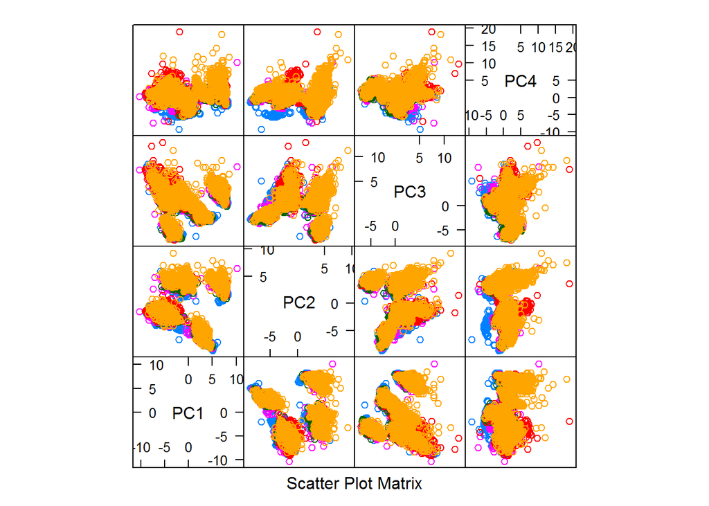

```r
pcaTraining <- predict(pcaObject, newdata = knnTraining)
featurePlot(pcaTraining[, 1:4], trainingClasse, plot = "pairs")
```

```r
model <- train(trainingClasse ~ ., data = pcaTraining, method = "rf")
testingClasse <- testing$classe
testing <- subset(testing, select = -classe)
testing <- testing[, -nzv]
testing <- subset(testing, select = -c(X, user_name, raw_timestamp_part_1, raw_timestamp_part_2, cvtd_timestamp, num_window))
knnTesting <- predict(knnObject, newdata = testing)
pcaTesting <- predict(pcaObject, newdata = knnTesting)
testingPrediction <- predict(model, newdata = pcaTesting)
confusionMatrix(testingPrediction, testingClasse)
```

```
## Confusion Matrix and Statistics
##
##           Reference
## Prediction    A    B    C    D    E
##          A 2134   44   18   16   15
##          B   29 1398   25    7   20
##          C   47   40 1288   84   32
##          D   12    8   20 1165   21
##          E   10   28   17   14 1354
##
## Overall Statistics
##
##                Accuracy : 0.9354
##                  95% CI : (0.9297, 0.9407)
##     No Information Rate : 0.2845
##     P-Value [Acc > NIR] : < 2.2e-16
##
##                   Kappa : 0.9183
##  Mcnemar's Test P-Value : 1.161e-10
##
## Statistics by Class:
##
##                      Class: A Class: B Class: C Class: D Class: E
## Sensitivity            0.9561   0.9209   0.9415   0.9059   0.9390
## Specificity            0.9834   0.9872   0.9687   0.9907   0.9892
## Pos Pred Value         0.9582   0.9452   0.8638   0.9502   0.9515
## Neg Pred Value         0.9826   0.9812   0.9874   0.9817   0.9863
## Prevalence             0.2845   0.1935   0.1744   0.1639   0.1838
## Detection Rate         0.2720   0.1782   0.1642   0.1485   0.1726
## Detection Prevalence   0.2838   0.1885   0.1900   0.1563   0.1814
## Balanced Accuracy      0.9698   0.9541   0.9551   0.9483   0.9641
```

The prediction algorithm, when applied to the testing set, has approximately 93.54% accuracy, which makes it a good prediction algorithm.